# Project 1

Kupriyanov Semyon

07 11 2021

# Project 1

### Short description:

Presents data on the Olympic Games over the past 120 years. The dataset has the following features:

*ID* – Unique number for each athlete *Name* – Athlete’s name *Sex* – M or F *Age* – Integer *Height* – In centimeters *Weight* – In kilograms *Team* – Team name *NOC* – National Olympic Committee 3-letter code *Games* – Year and season *Year* – Integer *Season* – Summer or Winter *City*– Host city *Sport* – Sport *Event* – Event *Medal* – Gold, Silver, Bronze, or NA

In this work, a statistical analysis of some data was carried out and a number of indicators were identified.

### Task 1.

#### Loading and collecting data.

The data is split into several files, presented in the “Data_folder” directory. To assemble data into a single dataset, the *“integrator”* function was written. The function takes two arguments: the path to the files, the extension of the files to be merged. *Both arguments must be strings*.

```r
integrator <- function(path_to_file, ind){
  setwd(path_to_file) #change the directory to the one specified in the argument
  names_of_files <- dir(getwd()) #vector with all files in directory
  is_ind <- function(x, ind){
    parts <- strsplit(x,".",fixed=TRUE)
    nparts <- length(parts[[1]])
    return(parts[[1]][nparts] == ind)
  } #function that determines the presence of the extension ind
  mk_table_csv <- function(x){
    return(read.csv(x))
  } #opens the file with read.csv
  mk_table_table <- function(x){
    return(read.table(x))
  } #opens the file with read.table
  table_maker <- function(named_vector, mk_table_f){
    just_table <- mk_table_f(named_vector[1])
    for (i in named_vector[-1]){
      just_table <- rbind(just_table, mk_table_f(i))
    }
    return(just_table)
  } #concatenates files from the specified vector into one
  if (ind == "csv"){
    finish_table <- table_maker(names_of_files[sapply(names_of_files,is_ind, ind)], mk_table_csv)

  } else{
    finish_table <- table_maker(names_of_files[sapply(names_of_files,is_ind, ind)], mk_table_table)

  }
  return(finish_table)
}
```

An example of a function call: *integrator(“C:/Users/username/OneDrive/Desktop/Project”, “csv”)* Upload the file:

```r
#path <- readline(prompt="Enter path to file: ")
#ind <- readline(prompt="Enter index, for example, 'csv': ")
path <- "C:/Users/pfft/OneDrive/Рабочий стол/БИ/R stat/Проект 1/Project"
ind <- "csv"
olimpic <- integrator(path, ind)
```

The data is loaded as an *olimpic* dataframe.

### Task 2.

Editing data. The data structure was looked at:

```r
str(olimpic)
```

```
## 'data.frame':    271116 obs. of  15 variables:
##  $ ID    : int  1 2 3 4 5 5 5 5 5 5 ...
##  $ Name  : chr  "A Dijiang" "A Lamusi" "Gunnar Nielsen Aaby" "Edgar Lindenau Aabye" ...
##  $ Sex   : chr  "M" "M" "M" "M" ...
##  $ Age   : int  24 23 24 34 21 21 25 25 27 27 ...
##  $ Height: int  180 170 NA NA 185 185 185 185 185 185 ...
##  $ Weight: num  80 60 NA NA 82 82 82 82 82 82 ...
##  $ Team  : chr  "China" "China" "Denmark" "Denmark/Sweden" ...
##  $ NOC   : chr  "CHN" "CHN" "DEN" "DEN" ...
##  $ Games : chr  "1992 Summer" "2012 Summer" "1920 Summer" "1900 Summer" ...
##  $ Year  : int  1992 2012 1920 1900 1988 1988 1992 1992 1994 1994 ...
##  $ Season: chr  "Summer" "Summer" "Summer" "Summer" ...
##  $ City  : chr  "Barcelona" "London" "Antwerpen" "Paris" ...
##  $ Sport : chr  "Basketball" "Judo" "Football" "Tug-Of-War" ...
##  $ Event : chr  "Basketball Men's Basketball" "Judo Men's Extra-Lightweight" "Football Men's Football" "Tug-Of-War Men's Tug-Of-War" ...
##  $ Medal : chr  NA NA NA "Gold" ...
```

All nominative variables with a small number of grades were converted to factors. After the transformation, the data structure became more accessible for initial assessment.

```r
str(olimpic)
```

```
## 'data.frame':    271116 obs. of  15 variables:
##  $ ID    : int  1 2 3 4 5 5 5 5 5 5 ...
##  $ Name  : chr  "A Dijiang" "A Lamusi" "Gunnar Nielsen Aaby" "Edgar Lindenau Aabye" ...
##  $ Sex   : Factor w/ 4 levels "","F","G","M": 4 4 4 4 2 2 2 2 2 2 ...
##  $ Age   : int  24 23 24 34 21 21 25 25 27 27 ...
##  $ Height: int  180 170 NA NA 185 185 185 185 185 185 ...
##  $ Weight: num  80 60 NA NA 82 82 82 82 82 82 ...
##  $ Team  : Factor w/ 1185 levels "","30. Februar",..: 200 200 274 279 706 706 706 706 706 706 ...
##  $ NOC   : Factor w/ 232 levels "","AFG","AHO",..: 43 43 57 57 148 148 148 148 148 148 ...
##  $ Games : chr  "1992 Summer" "2012 Summer" "1920 Summer" "1900 Summer" ...
##  $ Year  : int  1992 2012 1920 1900 1988 1988 1992 1992 1994 1994 ...
##  $ Season: Factor w/ 3 levels "","Summer","Winter": 2 2 2 2 3 3 3 3 3 3 ...
##  $ City  : chr  "Barcelona" "London" "Antwerpen" "Paris" ...
##  $ Sport : Factor w/ 68 levels "","Aeronautics",..: 10 35 27 64 56 56 56 56 56 56 ...
##  $ Event : chr  "Basketball Men's Basketball" "Judo Men's Extra-Lightweight" "Football Men's Football" "Tug-Of-War Men's Tug-Of-War" ...
##  $ Medal : Factor w/ 4 levels "","Bronze","Gold",..: NA NA NA 3 NA NA NA NA NA NA ...
```

The trait *sex* revealed unnecessary gradations (’’, G). The *Games* column duplicates information from the Season and Year columns. This is contrary to the concept of tidy date; the column can be removed.After deletion, the underlying statistics of quantitative factors can be viewed using the *summary()* function:

```r
olimpic$Games <- NULL
summary(olimpic)
```

```
##        ID             Name           Sex             Age
##  Min.   :     1   Length:271116       :     2   Min.   : 10.00
##  1st Qu.: 34643   Class :character   F: 74523   1st Qu.: 21.00
##  Median : 68205   Mode  :character   G:     2   Median : 24.00
##  Mean   : 68249                      M:196589   Mean   : 25.56
##  3rd Qu.:102097                                 3rd Qu.: 28.00
##  Max.   :135571                                 Max.   :240.00
##                                                 NA's   :9476
##      Height          Weight                 Team             NOC
##  Min.   :127.0   Min.   :  7.0   United States: 17847   USA    : 18853
##  1st Qu.:168.0   1st Qu.: 60.0   France       : 11988   FRA    : 12758
##  Median :175.0   Median : 70.0   Great Britain: 11404   GBR    : 12256
##  Mean   :175.3   Mean   : 70.7   Italy        : 10259   ITA    : 10713
##  3rd Qu.:183.0   3rd Qu.: 79.0   Germany      :  9326   GER    :  9830
##  Max.   :340.0   Max.   :214.0   Canada       :  9279   CAN    :  9733
##  NA's   :60172   NA's   :62876   (Other)      :201013   (Other):196973
##       Year         Season           City                  Sport
##  Min.   :1896         :     7   Length:271116      Athletics : 38623
##  1st Qu.:1960   Summer:222545   Class :character   Gymnastics: 26706
##  Median :1988   Winter: 48564   Mode  :character   Swimming  : 23195
##  Mean   :1978                                      Shooting  : 11448
##  3rd Qu.:2002                                      Cycling   : 10859
##  Max.   :2016                                      Fencing   : 10734
##  NA's   :7                                         (Other)   :149551
##     Event              Medal
##  Length:271116            :    10
##  Class :character   Bronze: 13295
##  Mode  :character   Gold  : 13372
##                     Silver: 13115
##                     NA's  :231324
##
##
```

The presence of additional empty factors in the variables *Sex*, *Age*, *Medal*, *Season* was revealed. Incorrect values are observed in the variables *Age*, *Height*, *Weight* (max in Age = 240 years, max in Height = 340 cm, min in Weight = 7 kg). The *dplyr* package was used to correct the data.

```r
summary(olimpic_cor)
```

```
##        ID             Name             Sex              Age
##  Min.   :     1   Length:271116      F   : 74523   Min.   :10.00
##  1st Qu.: 34643   Class :character   M   :196589   1st Qu.:21.00
##  Median : 68205   Mode  :character   NA's:     4   Median :24.00
##  Mean   : 68249                                    Mean   :25.52
##  3rd Qu.:102097                                    3rd Qu.:28.00
##  Max.   :135571                                    Max.   :66.00
##                                                    NA's   :9716
##      Height          Weight                 Team             NOC
##  Min.   :127.0   Min.   :  7.0   United States: 17847   USA    : 18853
##  1st Qu.:168.0   1st Qu.: 60.0   France       : 11988   FRA    : 12758
##  Median :175.0   Median : 70.0   Great Britain: 11404   GBR    : 12256
##  Mean   :175.3   Mean   : 70.7   Italy        : 10259   ITA    : 10713
##  3rd Qu.:183.0   3rd Qu.: 79.0   Germany      :  9326   GER    :  9830
##  Max.   :226.0   Max.   :214.0   Canada       :  9279   CAN    :  9733
##  NA's   :60173   NA's   :62876   (Other)      :201013   (Other):196973
##       Year         Season           City                  Sport
##  Min.   :1896   Summer:222545   Length:271116      Athletics : 38623
##  1st Qu.:1960   Winter: 48564   Class :character   Gymnastics: 26706
##  Median :1988   NA's  :     7   Mode  :character   Swimming  : 23195
##  Mean   :1978                                      Shooting  : 11448
##  3rd Qu.:2002                                      Cycling   : 10859
##  Max.   :2016                                      Fencing   : 10734
##  NA's   :7                                         (Other)   :149551
##     Event              Medal
##  Length:271116      Bronze: 13295
##  Class :character   Gold  : 13372
##  Mode  :character   Silver: 13115
##                     NA's  :231334
##
##
##
```

The corrected data is presented in the form of *olimpic_cor* dataframe. Initial data preparation is completed. Another way of viewing data and correcting them is graphical. You can build graphs, like boxplots, scatterplots, etc., to estimate emissions or other indicators. This approach was applied to other tasks during the work on sorted and filtered data, since the initial data is quite massive and their rendering does not always give a clear picture. Also, NA values have not been replaced or removed at this stage. This has also been done in other parts of the work on filtered and sorted data(to avoid data loss).

### Task 3.

The age of the youngest athletes of both sexes at the 1992 Olympics was established.For this task, the functionality of the *dplyr* package was used. The data was first filtered and sorted, the NA values were removed only for the feature of interest.Missing values have been removed after filtering and sorting the data using the min option *na.rm = T*.

```r
olimpic_cor %>% group_by(Sex) %>% filter(Year == 1992) %>% select(Age, Sex) %>% summarise(Min_Age = min(Age, na.rm = T))
```

```
## # A tibble: 2 x 2
##   Sex   Min_Age
##   <fct>   <int>
## 1 F          12
## 2 M          11
```

The minimum age *for females* was *12* years old, *for males* was *11* years old.

### Task 4.

The *mean* and *standard deviation* of the *Height* variable were calculated for athletes of each gender. Missing values have been removed after filtering and sorting the data using the *mean* and *sd* option *na.rm = T*.

```r
olimpic_cor %>% filter(Sex == "M" | Sex == "F") %>% group_by(Sex) %>% summarise(mean_height = mean(Height, na.rm = T), sd_height = sd(Height, na.rm = T))
```

```
## # A tibble: 2 x 3
##   Sex   mean_height sd_height
##   <fct>       <dbl>     <dbl>
## 1 F            168.      8.78
## 2 M            179.      9.36
```

For women, the mean and standard deviation of height was *168*, *8.78*, respectively. For men, the mean and standard deviation of height was *179*, *9.36*, respectively.

### Task 5.

The *mean* and *standard deviation* of the *Height* variable were calculated for *female tennis players (sex = F) at the 2000 Olympics*. Missing values have been removed after filtering and sorting the data using the *mean* and *sd* option *na.rm = T*. The answer was rounded to the first character after the separator.

```r
olimpic_cor %>% filter(Year == 2000 & Sex == "F" & Sport == "Tennis") %>% summarise(Tennis_female_mean_height = round(mean(Height, na.rm = T), digits = 1), Tennis_female_sd_height = round(sd(Height, na.rm = T), digits = 1))
```

```
##   Tennis_female_mean_height Tennis_female_sd_height
## 1                     171.8                     6.5
```

The *average* was *171.8* cm; the standard deviation was *6.5* cm.

### Task 6.

```r
hard_sport_2006 <- olimpic_cor %>% filter(Year == 2006)
hard_sport_2006[which.max(hard_sport_2006$Height), c(2, 13)]
```

```
##           Name                       Event
## 577 Zdeno Chra Ice Hockey Men's Ice Hockey
```

### Task 7.

The number of *gold medals* received by *women from 1980 to 2010* was determined.

```r
olimpic_cor %>% filter(Year >= 1980 & Year <= 2010 & Sex == "F" & Medal == "Gold") %>% summarise(Number_of_gold_medals = n())
```

```
##   Number_of_gold_medals
## 1                  2249
```

*2,249 gold medals* were received.

### Task 8.

In this part of the work, the athlete *John Aalberg* was studied. The number of his participation in the Olympic Games was investigated. First, the data was filtered with the following result:

```r
olimpic_cor %>% filter(Name == "John Aalberg") %>% select(Year, Name)
```

```
##   Year         Name
## 1 1992 John Aalberg
## 2 1992 John Aalberg
## 3 1992 John Aalberg
## 4 1992 John Aalberg
## 5 1994 John Aalberg
## 6 1994 John Aalberg
## 7 1994 John Aalberg
## 8 1994 John Aalberg
```

They determined that *John Aalberg* participated *8* times, 4 times in 1992 and 4 times in 1994. The viewing range was expanded:

```r
olimpic_cor %>% filter(Name == "John Aalberg") %>% select(Year, Season, Name, Event)
```

```
##   Year Season         Name                                               Event
## 1 1992 Winter John Aalberg            Cross Country Skiing Men's 10 kilometres
## 2 1992 Winter John Aalberg            Cross Country Skiing Men's 50 kilometres
## 3 1992 Winter John Aalberg Cross Country Skiing Men's 10/15 kilometres Pursuit
## 4 1992 Winter John Aalberg  Cross Country Skiing Men's 4 x 10 kilometres Relay
## 5 1994 Winter John Aalberg            Cross Country Skiing Men's 10 kilometres
## 6 1994 Winter John Aalberg            Cross Country Skiing Men's 30 kilometres
## 7 1994 Winter John Aalberg Cross Country Skiing Men's 10/15 kilometres Pursuit
## 8 1994 Winter John Aalberg  Cross Country Skiing Men's 4 x 10 kilometres Relay
```

Thus, *John Aalberg* participated in the Olympic Games *twice*: in *1992* and *1994*. He took part in *4 competitions* at once.

### Task 9.

```r
olimpic_2008_periods <- olimpic_cor %>% mutate(Age_period = sapply(olimpic_cor$Age, function(x) ifelse(x<25 & x>=15, "15-24", ifelse(x<35 & x>=25, "25-34", ifelse(x<45 & x>=35, "35-44", ifelse(x<=55 & x >=45, "45-55", "Other"))))))
olimpic_2008_periods$Age_period <- factor(olimpic_2008_periods$Age_period)
olimpic_2008_periods %>% group_by(Age_period) %>% summarise(Count = n())
```

```
## # A tibble: 6 x 2
##   Age_period  Count
##   <fct>       <int>
## 1 15-24      130056
## 2 25-34      110990
## 3 35-44       15110
## 4 45-55        3377
## 5 Other        1867
## 6 <NA>         9716
```

The results were visualized on a graph using the *ggplot 2* library (in addition, the gender distribution was visualized):

[figure not shown]

Thus, the two most represented age groups are: *[15-25)*, *[25-35)*. This is due to the fact that the main professional activity and career of athletes falls on this age period (~20-30 years). The sex composition shows that male athletes prevail in all age groups.

### Task 10.

The dynamics of *the number of sports* in the *2002* Olympics compared to the *1994* Olympics was analyzed.

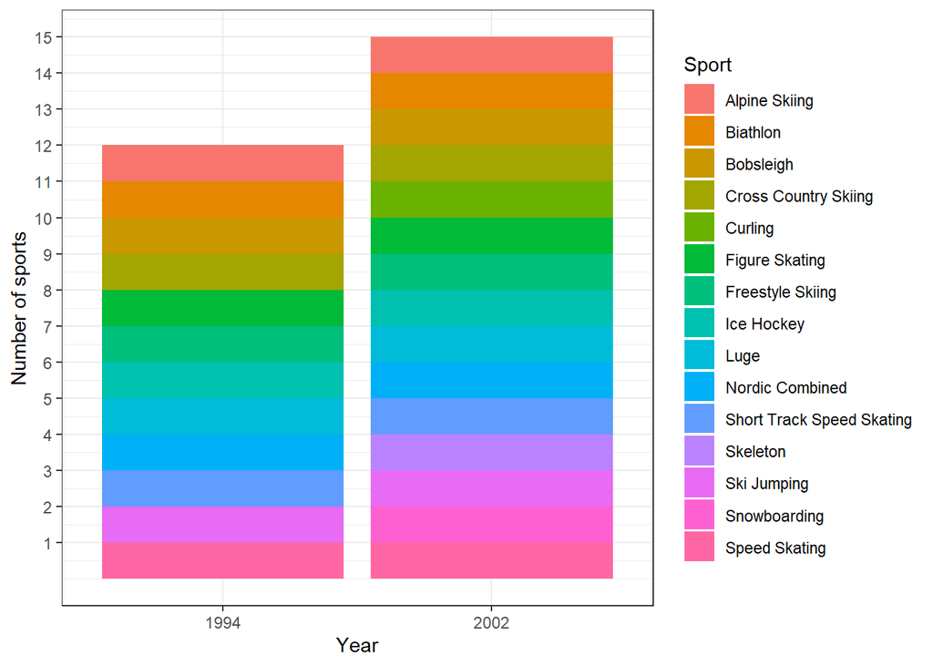

*Three new sports* are present in 2002 compared to 1994 (*15* versus *12* sports, respectively). These sports are: *Curling*, *Skeleton*, *Snowboarding*.

### Task 11.

For each season, the *top 3 countries* were identified *for each type of medal*.

```r
# Gold
olimpic_cor %>% group_by(Season, NOC) %>% filter(Medal == "Gold", Season == "Winter") %>% summarise(num_for_gold = n()) %>% arrange(desc(num_for_gold)) %>% slice(1:3)
```

```
## # A tibble: 3 x 3
## # Groups:   Season [1]
##   Season NOC   num_for_gold
##   <fct>  <fct>        <int>
## 1 Winter CAN            305
## 2 Winter URS            250
## 3 Winter USA            166
```

```r
olimpic_cor %>% group_by(Season, NOC) %>% filter(Medal == "Gold", Season == "Summer") %>% summarise(num_for_gold = n()) %>% arrange(desc(num_for_gold)) %>% slice(1:3)
```

```
## # A tibble: 3 x 3
## # Groups:   Season [1]
##   Season NOC   num_for_gold
##   <fct>  <fct>        <int>
## 1 Summer USA           2472
## 2 Summer URS            832
## 3 Summer GBR            636
```

```r
# Silver
olimpic_cor %>% group_by(Season, NOC) %>% filter(Medal == "Silver", Season == "Winter") %>% summarise(num_for_silver = n()) %>% arrange(desc(num_for_silver)) %>% slice(1:3)
```

```
## # A tibble: 3 x 3
## # Groups:   Season [1]
##   Season NOC   num_for_silver
##   <fct>  <fct>          <int>
## 1 Winter USA              308
## 2 Winter CAN              199
## 3 Winter NOR              165
```

```r
olimpic_cor %>% group_by(Season, NOC) %>% filter(Medal == "Silver", Season == "Summer") %>% summarise(num_for_silver = n()) %>% arrange(desc(num_for_silver)) %>% slice(1:3)
```

```
## # A tibble: 3 x 3
## # Groups:   Season [1]
##   Season NOC   num_for_silver
##   <fct>  <fct>          <int>
## 1 Summer USA             1333
## 2 Summer GBR              729
## 3 Summer URS              635
```

```r
# Bronze
olimpic_cor %>% group_by(Season, NOC) %>% filter(Medal == "Bronze", Season == "Winter") %>% summarise(num_for_bronze = n()) %>% arrange(desc(num_for_bronze)) %>% slice(1:3)
```

```
## # A tibble: 3 x 3
## # Groups:   Season [1]
##   Season NOC   num_for_bronze
##   <fct>  <fct>          <int>
## 1 Winter FIN              215
## 2 Winter SWE              177
## 3 Winter USA              161
```

```r
olimpic_cor %>% group_by(Season, NOC) %>% filter(Medal == "Bronze", Season == "Summer") %>% summarise(num_for_bronze = n()) %>% arrange(desc(num_for_bronze)) %>% slice(1:3)
```

```
## # A tibble: 3 x 3
## # Groups:   Season [1]
##   Season NOC   num_for_bronze
##   <fct>  <fct>          <int>
## 1 Summer USA             1197
## 2 Summer GER              649
## 3 Summer GBR              620
```

### Task 12.

*Z-standardization* was carried out for the variable *Height*.Missing values have been removed after filtering and sorting the data using the *mean* and *sd* option *na.rm = T* (ensuring the correct operation of functions).The implementation was done using the basic R functionality.

```r
Height_z_scores <- (olimpic_cor$Height - mean(olimpic_cor$Height, na.rm = T))/sd(olimpic_cor$Height, na.rm = T)
olimpic_cor$Height_z_scores <- Height_z_scores
str(olimpic_cor)
```

```
## 'data.frame':    271116 obs. of  15 variables:
##  $ ID             : int  1 2 3 4 5 5 5 5 5 5 ...
##  $ Name           : chr  "A Dijiang" "A Lamusi" "Gunnar Nielsen Aaby" "Edgar Lindenau Aabye" ...
##  $ Sex            : Factor w/ 2 levels "F","M": 2 2 2 2 1 1 1 1 1 1 ...
##  $ Age            : int  24 23 24 34 21 21 25 25 27 27 ...
##  $ Height         : int  180 170 NA NA 185 185 185 185 185 185 ...
##  $ Weight         : num  80 60 NA NA 82 82 82 82 82 82 ...
##  $ Team           : Factor w/ 1185 levels "","30. Februar",..: 200 200 274 279 706 706 706 706 706 706 ...
##  $ NOC            : Factor w/ 232 levels "","AFG","AHO",..: 43 43 57 57 148 148 148 148 148 148 ...
##  $ Year           : int  1992 2012 1920 1900 1988 1988 1992 1992 1994 1994 ...
##  $ Season         : Factor w/ 2 levels "Summer","Winter": 1 1 1 1 2 2 2 2 2 2 ...
##  $ City           : chr  "Barcelona" "London" "Antwerpen" "Paris" ...
##  $ Sport          : Factor w/ 68 levels "","Aeronautics",..: 10 35 27 64 56 56 56 56 56 56 ...
##  $ Event          : chr  "Basketball Men's Basketball" "Judo Men's Extra-Lightweight" "Football Men's Football" "Tug-Of-War Men's Tug-Of-War" ...
##  $ Medal          : Factor w/ 3 levels "Bronze","Gold",..: NA NA NA 2 NA NA NA NA NA NA ...
##  $ Height_z_scores: num  0.443 -0.508 NA NA 0.918 ...
```

### Task 13.

*Min-max normalization* was applied to the *Height* variable.The implementation was done using the *dplyr* functionality.

```r
str(olimpic_cor)
```

```
## 'data.frame':    271116 obs. of  16 variables:
##  $ ID                   : int  1 2 3 4 5 5 5 5 5 5 ...
##  $ Name                 : chr  "A Dijiang" "A Lamusi" "Gunnar Nielsen Aaby" "Edgar Lindenau Aabye" ...
##  $ Sex                  : Factor w/ 2 levels "F","M": 2 2 2 2 1 1 1 1 1 1 ...
##  $ Age                  : int  24 23 24 34 21 21 25 25 27 27 ...
##  $ Height               : int  180 170 NA NA 185 185 185 185 185 185 ...
##  $ Weight               : num  80 60 NA NA 82 82 82 82 82 82 ...
##  $ Team                 : Factor w/ 1185 levels "","30. Februar",..: 200 200 274 279 706 706 706 706 706 706 ...
##  $ NOC                  : Factor w/ 232 levels "","AFG","AHO",..: 43 43 57 57 148 148 148 148 148 148 ...
##  $ Year                 : int  1992 2012 1920 1900 1988 1988 1992 1992 1994 1994 ...
##  $ Season               : Factor w/ 2 levels "Summer","Winter": 1 1 1 1 2 2 2 2 2 2 ...
##  $ City                 : chr  "Barcelona" "London" "Antwerpen" "Paris" ...
##  $ Sport                : Factor w/ 68 levels "","Aeronautics",..: 10 35 27 64 56 56 56 56 56 56 ...
##  $ Event                : chr  "Basketball Men's Basketball" "Judo Men's Extra-Lightweight" "Football Men's Football" "Tug-Of-War Men's Tug-Of-War" ...
##  $ Medal                : Factor w/ 3 levels "Bronze","Gold",..: NA NA NA 2 NA NA NA NA NA NA ...
##  $ Height_z_scores      : num  0.443 -0.508 NA NA 0.918 ...
##  $ Height_min_max_scaled: num  0.535 0.434 NA NA 0.586 ...
```

### Task 14.

Statistical analysis of the Age, Height, Weight variables was performed. At the first step, the mean and standard deviation were calculated in the respective groups:

```
## # A tibble: 2 x 3
##   Sex   Mean_Age Sd_Age
##   <fct>    <dbl>  <dbl>
## 1 F         24.0   4.69
## 2 M         25.5   4.75
```

```
## # A tibble: 2 x 3
##   Sex   Mean_Height Sd_Height
##   <fct>       <dbl>     <dbl>
## 1 F            167.      6.03
## 2 M            179.      6.59
```

```
## # A tibble: 2 x 3
##   Sex   Mean_Weight Sd_Weight
##   <fct>       <dbl>     <dbl>
## 1 F            59.8      7.06
## 2 M            76.4     10.3
```

To study the differences in these quantitative traits in the two sex groups, a comparison of the sample means was chosen. To determine the statistical test, a graphical analysis of the distributions of these quantities was carried out.

#### Age distribution:

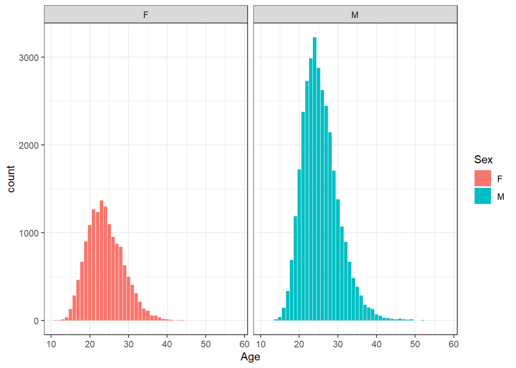

#### Height distribution:

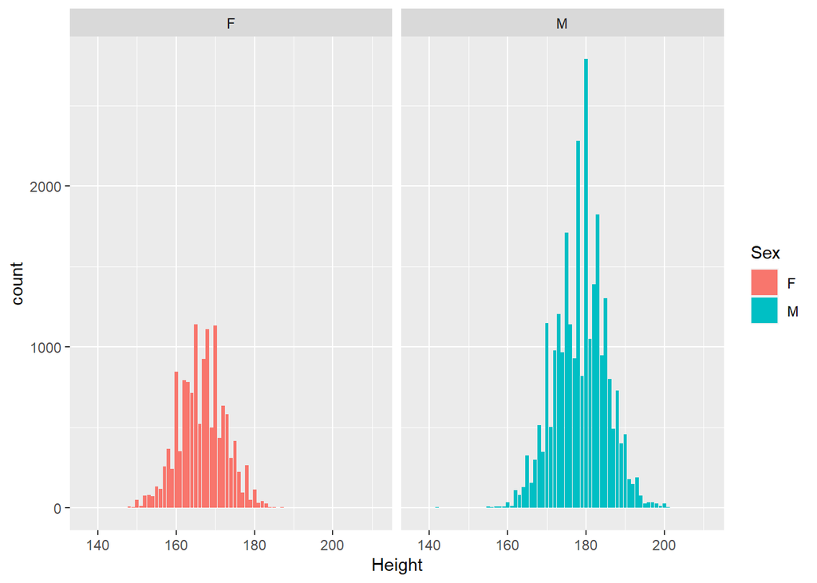

[output not shown]

[output cut: 365 more lines]

[output not shown]

#### Weight distribution:

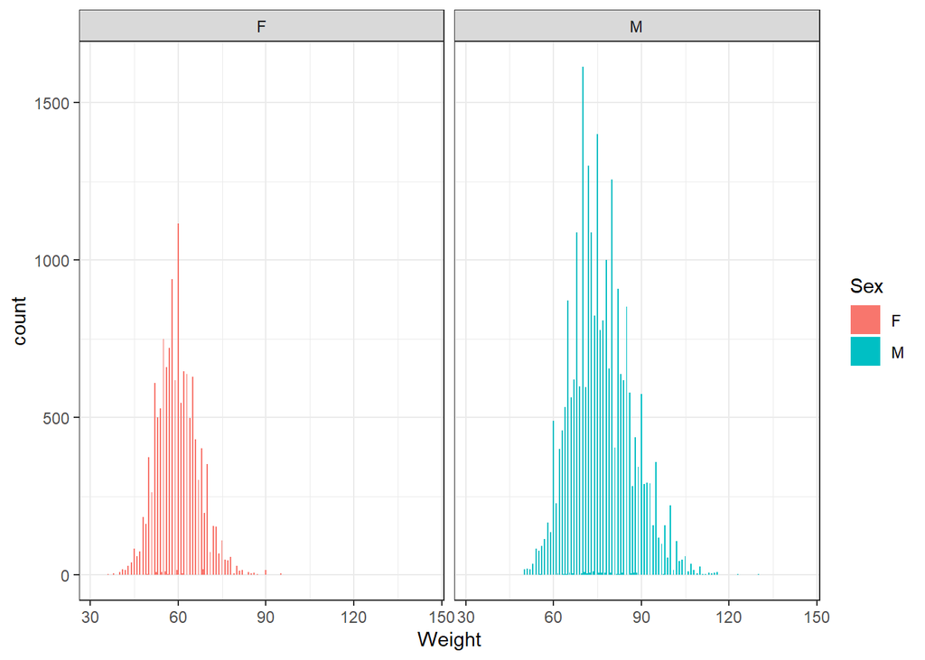

*QQ-plots* were also built:

#### Age distribution for women:

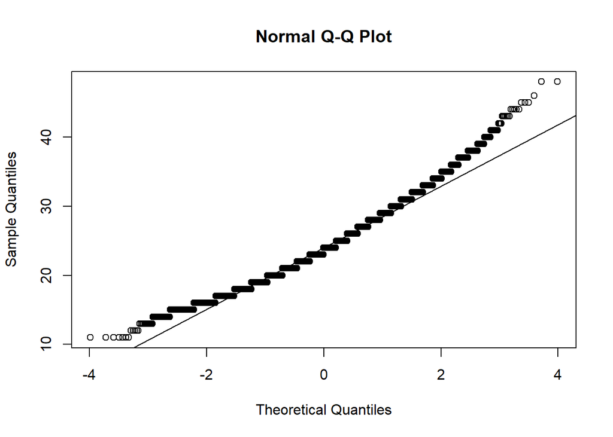

#### Age distribution for men:

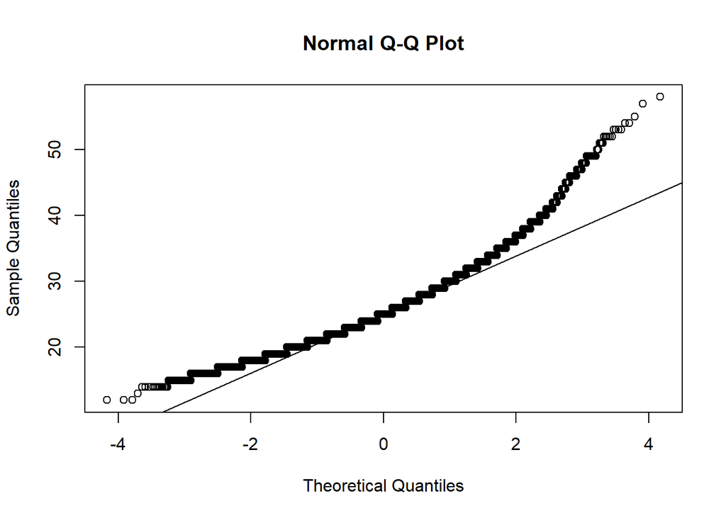

#### Height distribution for women:

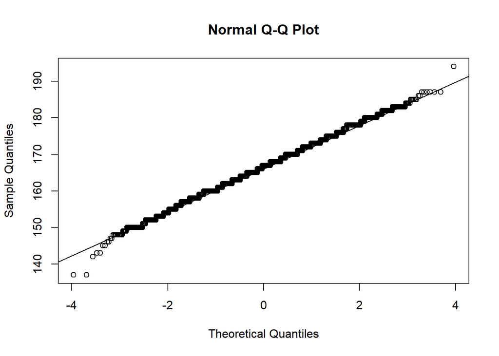

#### Height distribution for men:

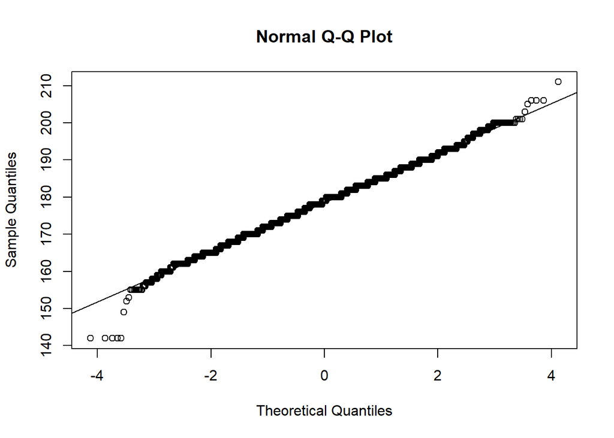

#### Weight distribution for women:

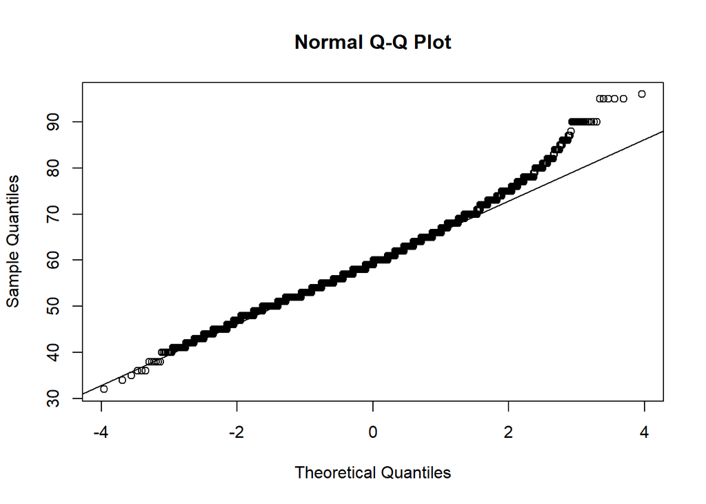

#### Weight distribution for men:

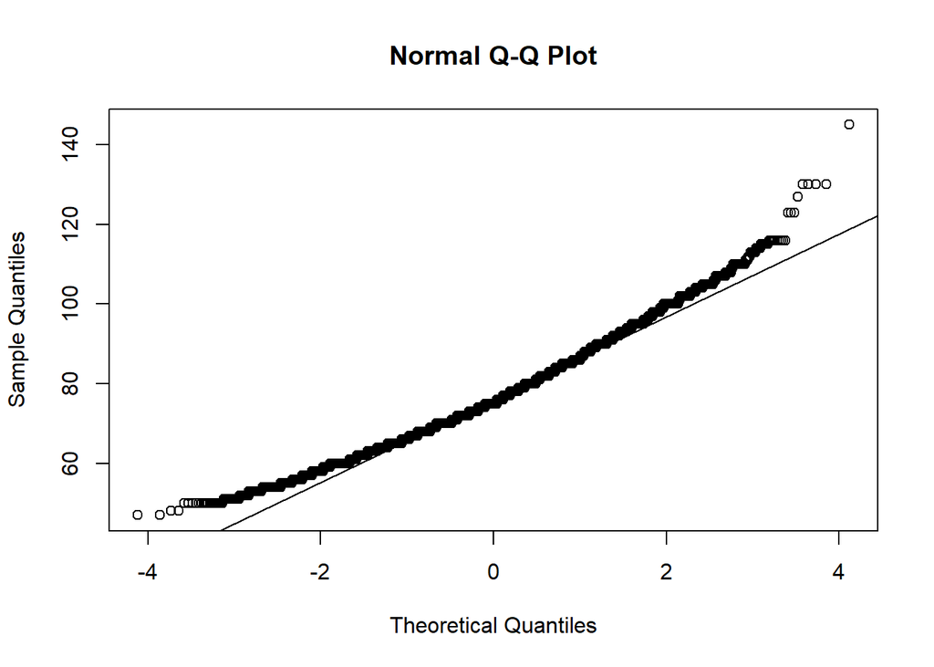

Based on the visualization results, it was concluded that the *distribution for the Age and Weight variables is not normal distribution* (especially for the Age variable). The *Height* variable has a fairly *close to normal distribution*. Thus, to analyze the difference in the means, the *t-test (Student’s test)* was applied to the Height variable; for the Age and Weight variables, the *nonparametric* test, *Mann-Whitney test* was used.

The nonparametric Mann-Whitney test was chosen in part because the Age and Weight distributions showed *one-sided bias* in both sex groups.

For both the t-test and the Mann-Whitney test, a *two-sample option* was used (to compare the means of the two samples). Since the initial study of the data found that the means of all three variables in the male groups were higher, the *one-sided versions* of the t-test and the Mann-Whitney test were used.

#### Age testing:

```r
Age_test <- wilcox.test(winter_games$Age[winter_games$Sex == "M"], winter_games$Age[winter_games$Sex == "F"], alternative="greater")
cat("Method: ", Age_test$method,"Statistic: ", Age_test$statistic, "p-value: ", Age_test$p.value)
```

```
## Method:  Wilcoxon rank sum test with continuity correction Statistic:  294473922 p-value:  2.01539e-214
```

#### Weight testing:

```r
Weight_test <-wilcox.test(winter_games$Weight[winter_games$Sex == "M"], winter_games$Weight[winter_games$Sex == "F"], alternative="greater")
wilcox.test(winter_games$Weight[winter_games$Sex == "M"], winter_games$Weight[winter_games$Sex == "F"], alternative="greater")
```

```
##
##  Wilcoxon rank sum test with continuity correction
##
## data:  winter_games$Weight[winter_games$Sex == "M"] and winter_games$Weight[winter_games$Sex == "F"]
## W = 319887210, p-value < 2.2e-16
## alternative hypothesis: true location shift is greater than 0
```

```r
cat("Method: ", Weight_test$method,"Statistic: ", Weight_test$statistic, "p-value: ", Weight_test$p.value)
```

```
## Method:  Wilcoxon rank sum test with continuity correction Statistic:  319887210 p-value:  0
```

#### Height testing:

```r
Height_test <- t.test(winter_games$Height[winter_games$Sex == "M"], winter_games$Height[winter_games$Sex == "F"], alternative="greater")
t.test(winter_games$Height[winter_games$Sex == "M"], winter_games$Height[winter_games$Sex == "F"], alternative="greater")
```

```
##
##  Welch Two Sample t-test
##
## data:  winter_games$Height[winter_games$Sex == "M"] and winter_games$Height[winter_games$Sex == "F"]
## t = 184.8, df = 29342, p-value < 2.2e-16
## alternative hypothesis: true difference in means is greater than 0
## 95 percent confidence interval:
##  12.03278      Inf
## sample estimates:
## mean of x mean of y
##  178.6691  166.5283
```

```r
cat("Method: ", Height_test$method,"Statistic: ", Height_test$statistic, "p-value: ", Height_test$p.value, "Df:", Height_test$parameter)
```

```
## Method:  Welch Two Sample t-test Statistic:  184.7964 p-value:  0 Df: 29342.42
```

#### The results are presented in the graphs:

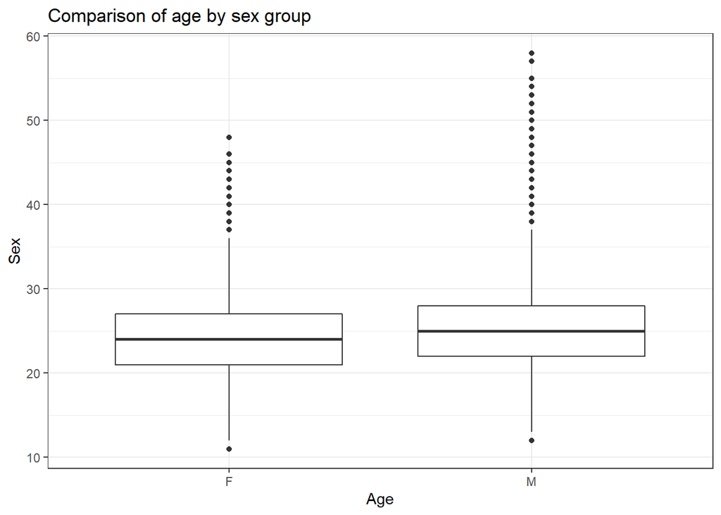

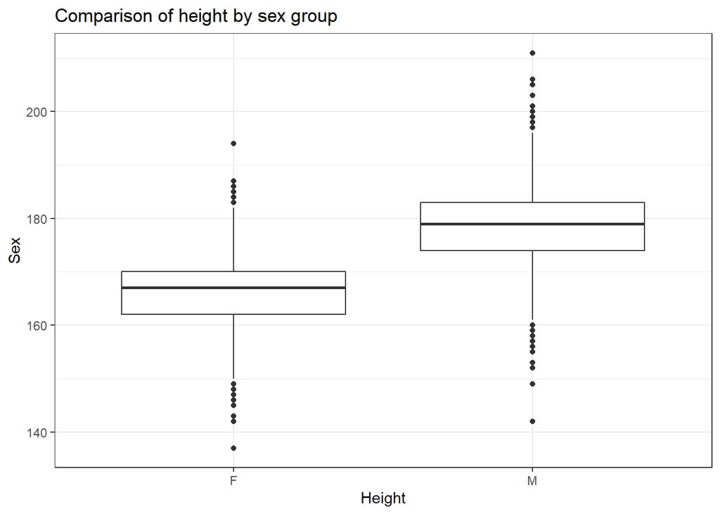

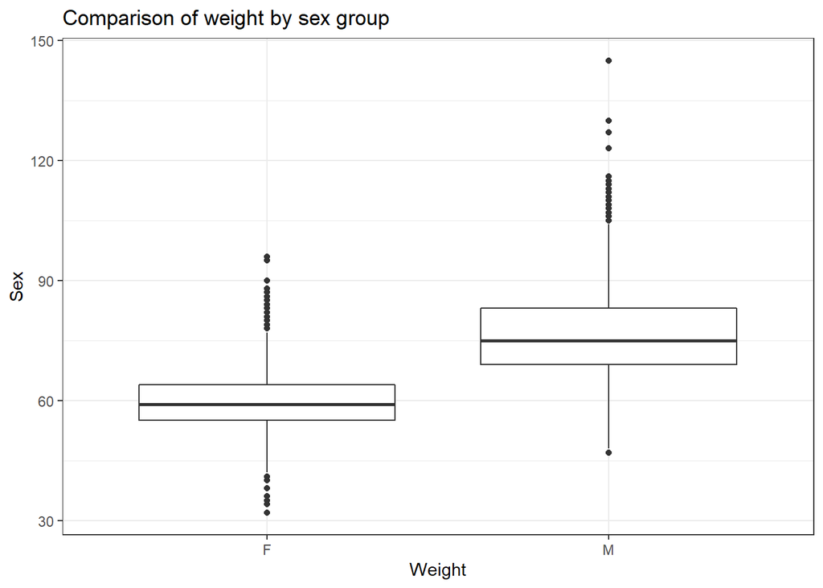

Statistical analysis of the Age, Height, Weight variables was performed.

To study the differences in these quantitative traits in the two sex groups, a comparison of the sample means was chosen. To determine the statistical test, a graphical analysis of the distributions of these quantities was carried out.

Based on the visualization results, it was concluded that the distribution for the Age and Weight variables is not normal (especially for the Age variable). The Height variable has a fairly close to normal distribution. Thus, to analyze the difference in the means, the t-test (Student’s test) was applied to the Height variable; for the Age and Weight variables, the nonparametric Mann-Whitney test was used.

The nonparametric Mann-Whitney test was chosen in part because the Age and Weight distributions showed one-sided bias in both sex groups.

For both the t-test and the Mann-Whitney test, a two-sample option was used (to compare the means of the two samples). Since the initial study of the data found that the means of all three variables in the male groups were higher, the one-sided versions of the t-test and the Mann-Whitney test were used.

The data were analyzed for outliers. A large number of outliers were recorded. With a large number of observations, the t-test is sufficiently robust to outliers, and nonparametric tests are initially robust to outliers. However, a parallel check was carried out. Outliers have been removed by filtration. The parameters for filtering were set using boxplots.

```r
winter_games2 <- winter_games %>% filter(Age < 37 & Age > 12)
winter_games2 <- winter_games2 %>% filter(Sex == "F" & Height < 182 & Height > 149 | Sex == "M" & Height < 196 & Height > 160)
winter_games2 <- winter_games2 %>% filter(Sex == "F" & Weight < 75 & Height > 49 | Sex == "M" & Weight < 101)
```

The tests were re-run. #### Age testing 2:

```r
Age_test2 <- wilcox.test(winter_games2$Age[winter_games2$Sex == "M"], winter_games2$Age[winter_games2$Sex == "F"], alternative="greater")
cat("Method: ", Age_test2$method,"Statistic: ", Age_test2$statistic, "p-value: ", Age_test2$p.value)
```

```
## Method:  Wilcoxon rank sum test with continuity correction Statistic:  182572262 p-value:  4.655346e-118
```

#### Weight testing 2:

```r
Weight_test2 <-wilcox.test(winter_games2$Weight[winter_games2$Sex == "M"], winter_games2$Weight[winter_games2$Sex == "F"], alternative="greater")
wilcox.test(winter_games2$Weight[winter_games$Sex == "M"], winter_games2$Weight[winter_games2$Sex == "F"], alternative="greater")
```

```
##
##  Wilcoxon rank sum test with continuity correction
##
## data:  winter_games2$Weight[winter_games$Sex == "M"] and winter_games2$Weight[winter_games2$Sex == "F"]
## W = 262950499, p-value < 2.2e-16
## alternative hypothesis: true location shift is greater than 0
```

```r
cat("Method: ", Weight_test2$method,"Statistic: ", Weight_test2$statistic, "p-value: ", Weight_test2$p.value)
```

```
## Method:  Wilcoxon rank sum test with continuity correction Statistic:  297066937 p-value:  0
```

#### Height testing 2:

```r
Height_test2 <- t.test(winter_games2$Height[winter_games2$Sex == "M"], winter_games2$Height[winter_games2$Sex == "F"], alternative="greater")
t.test(winter_games2$Height[winter_games2$Sex == "M"], winter_games2$Height[winter_games2$Sex == "F"], alternative="greater")
```

```
##
##  Welch Two Sample t-test
##
## data:  winter_games2$Height[winter_games2$Sex == "M"] and winter_games2$Height[winter_games2$Sex == "F"]
## t = 191.22, df = 27666, p-value < 2.2e-16
## alternative hypothesis: true difference in means is greater than 0
## 95 percent confidence interval:
##  12.169    Inf
## sample estimates:
## mean of x mean of y
##  178.5536  166.2790
```

```r
cat("Method: ", Height_test2$method,"Statistic: ", Height_test2$statistic, "p-value: ", Height_test2$p.value, "Df:", Height_test2$parameter)
```

```
## Method:  Welch Two Sample t-test Statistic:  191.2178 p-value:  0 Df: 27666.43
```

#### The filtered data plots are shown below:

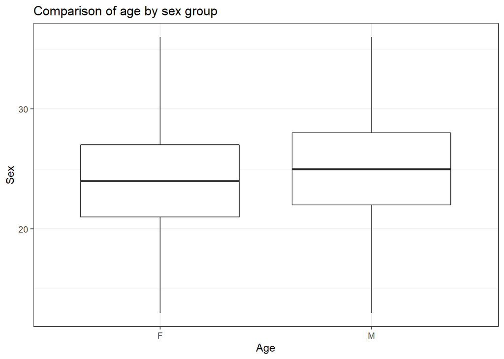

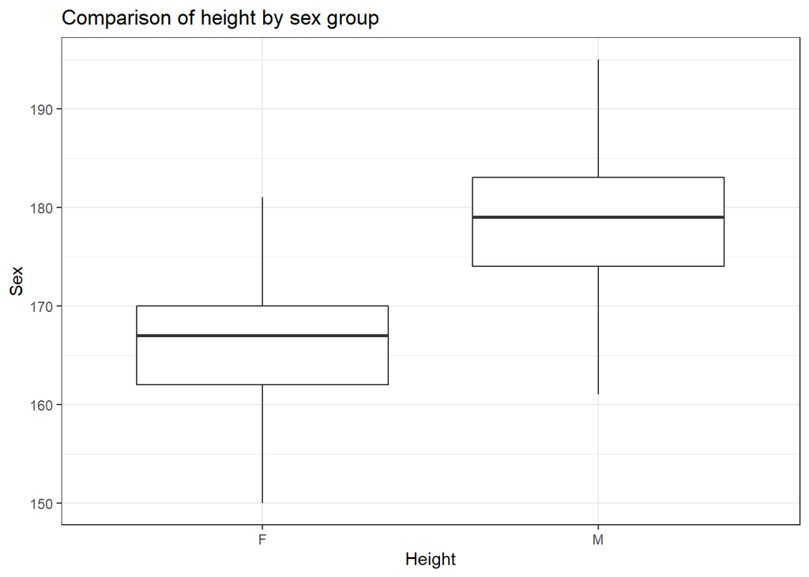

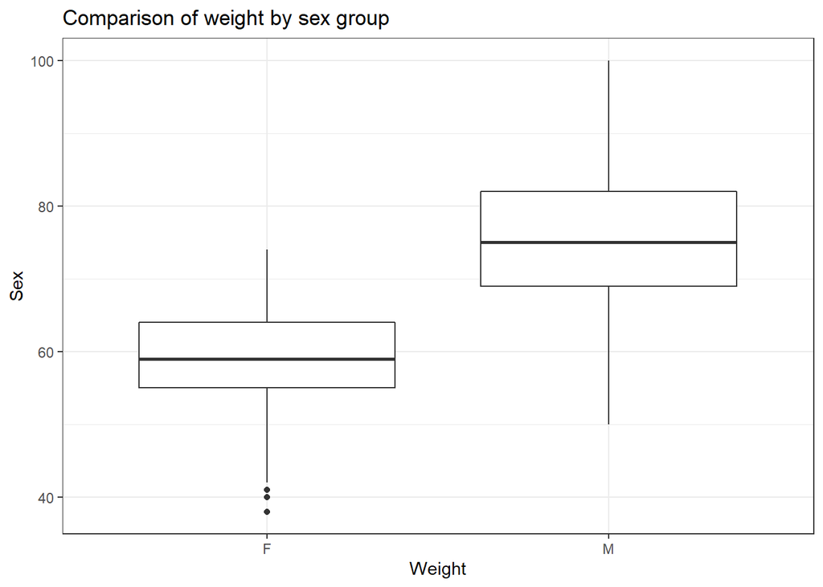

Thus, outliers did not significantly affect the values of the statistics probably due to the large number of observations.

On the basis of statistical checks, we can say that in men, age, height and weight differ significantly in a larger direction from women. Nevertheless, on the basis of boxplots, it can be seen that differences in age are not significantly expressed. The statistical significance is probably related to the large number of observations.

#### Thus, it is safe to say that the height and weight of male athletes at the Winter Olympic Games is significantly greater than that of female athletes.

### Task 15.

The variables *Team* and *Medal* were examined. The data has been converted. The NA values have been removed using the *na.omit* function from the *data.table* package.

```r
library(data.table)
Team_Medal <- olimpic_cor %>% select(Team, Medal)
Team_Medal <- na.omit(Team_Medal)
```

The distribution of the number of medals among all teams was investigated.

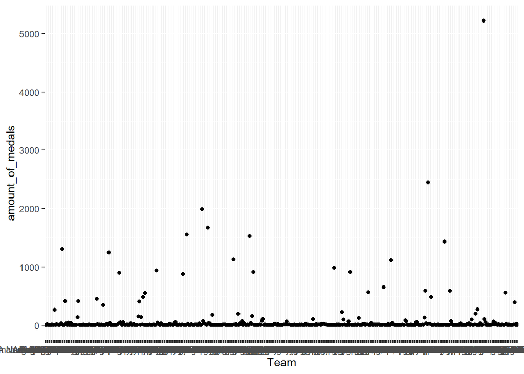

```r
Team_amount_of_medals <- Team_Medal %>% group_by(Team) %>% summarise(amount_of_medals = n())
ggplot(Team_amount_of_medals, aes(Team, amount_of_medals))+geom_point()
```

The graph shows that the distribution can be divided into two parts according to the number of medals.The following graph shows the division of the distribution of the number of medals by medal type.An additional elevation has been added to the Y-axis.

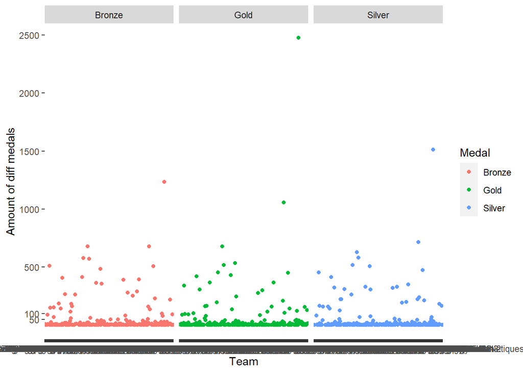

The graph demonstrates a similar division across all three groups.It was determined that the data is divided into *two parts*: *teams with more than 50 medals* and *teams with less than 50 medals*.The data was divided into 2 groups.

```r
High_medal <- Team_amount_of_diff_medals %>% filter(amount_of_diff_medals > 50)
Low_medal <- Team_amount_of_diff_medals %>% filter(amount_of_diff_medals < 50)
```

#### Distribution of medals among teams with more than 50 medals

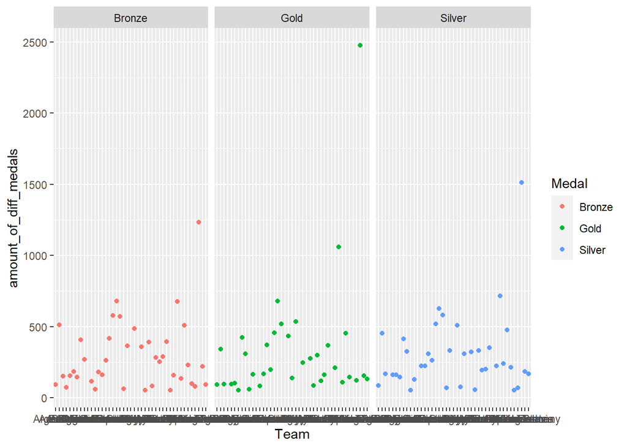

#### Distribution of medals among teams with less than 50 medals

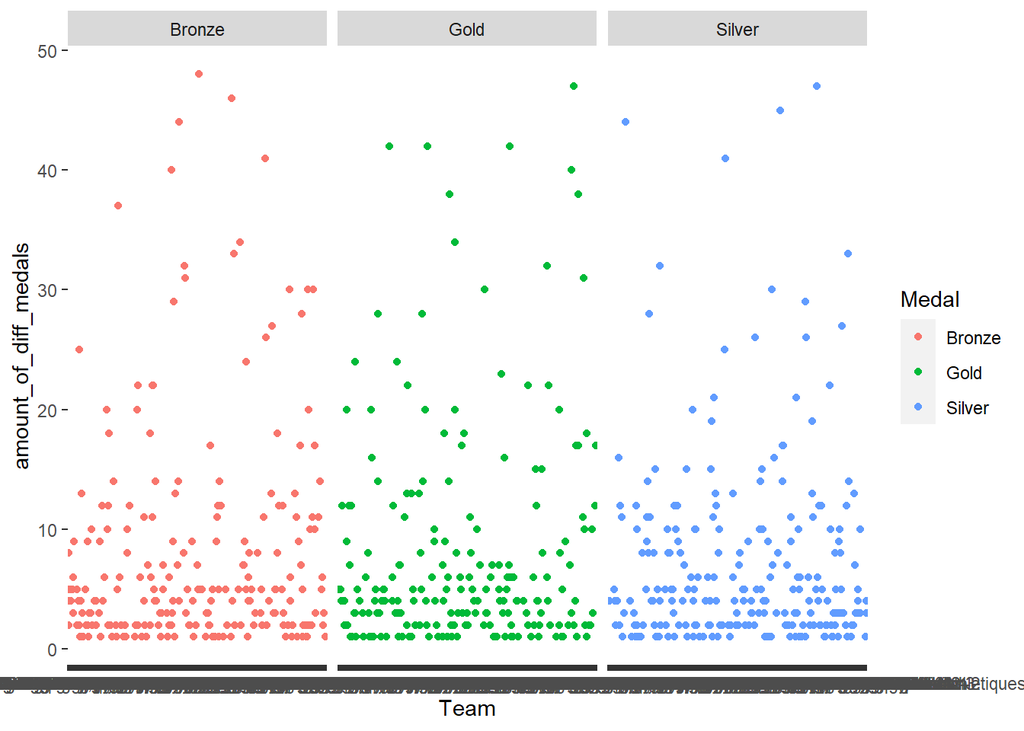

#### CONCLUSIONS:

1. Teams can be divided according to their level of training into teams with a high level and teams with a low level, as evidenced by the number of medals earned;
2. One could look at the composition of countries in these two groups, compare their GDP and spending on sports and try to relate living standards and incomes in the country with the success at the Olympics;
3. The type of medal, in this case, depends more on some other circumstances, since distribution in all groups is more or less the same.

Clustering techniques could be used to study the relationship between these variables. Nevertheless, based on their interaction, it can be assumed that there is a third variable (or a group of variables) that affects how many medals a team can receive (these influences will not apply to the type of medal).

### Conclusion

This paper demonstrates R’s ability to explore a variety of data. A relatively large amount of data was processed using special tools of the R language. Several regularities were revealed between the anthropometric indicators of Olympic athletes. Also, the limitations in the use of standard methods of statistical testing of hypotheses with data of a sufficiently large volume were shown and the advantages of a graphical approach were shown.

[output not shown]